# Final_PHD_code

**Name:** Dolly Bonde

**Problem Statment:** Sentiment Analysis of "The Lion king(1029)" Movie Reviews.

**Objective:** To Analyize the audience's response for the movie and understand what aspects of the movie can be improved. As this movie was a remake of Disney's 1994 Original movie, we can also find out if such remakes will be Profitable or not in future.

**Table of Content:**

1. Data Collection
2. EDA and Data Visualization
3. Model Building
4. Cluster Analysis
5. Summary And Recommendation

```python
import warnings
warnings.filterwarnings("ignore")
import requests
import time
import json
import pandas as pd
pd.set_option("display.max_colwidth",-1)
import numpy as np
import re
import string
import math

from wordcloud import WordCloud
import matplotlib.pyplot as plt
%matplotlib inline
import seaborn as sns
sns.set_style('whitegrid')
from sklearn.manifold import TSNE
from vec2graph import visualize
import networkx as nx

import nltk
from nltk.tokenize import sent_tokenize, word_tokenize
from nltk.corpus import stopwords
from collections import Counter
from nltk.util import ngrams
import spacy
nlp = spacy.load("en")
from spacy.tokens import Doc
from vaderSentiment.vaderSentiment import SentimentIntensityAnalyzer
from textblob import TextBlob

import emot
import demoji
#demoji.download_codes()
# from spellchecker import SpellChecker
# from autocorrect import spell

from contractions import CONTRACTION_MAP
import unicodedata

import gensim
from gensim.models import word2vec


from sklearn.feature_extraction.text import TfidfVectorizer
from sklearn.svm import SVC
from sklearn.ensemble import RandomForestClassifier
from sklearn.linear_model import LogisticRegression
from sklearn.decomposition import PCA
from mlxtend.plotting import category_scatter
from sklearn.cluster import KMeans
from sklearn.neighbors import KNeighborsClassifier

from keras.preprocessing.text import Tokenizer
from keras.preprocessing.sequence import pad_sequences
from keras.utils import to_categorical
from keras.layers import Input,Embedding,Dense,Flatten,concatenate,LSTM
from keras.layers import Dropout,Conv1D,GlobalMaxPooling1D,MaxPooling1D

from keras.models import Model, Sequential, load_model
from keras.callbacks import LearningRateScheduler,ModelCheckpoint
```

###### Initializing the parameter

```python
headers = {
'Referer': 'https://www.rottentomatoes.com/m/the_lion_king_2019/reviews?type=user',
'User-Agent': 'Chrome/74.0.3729.108 ',
'X-Requested-With': 'XMLHttpRequest',
}

url = 'https://www.rottentomatoes.com/napi/movie/9057c2cf-7cab-317f-876f-e50b245ca76e/reviews/user'
endcursor = ''
startcursor = ''
```

###### Loading First page

```python
payload = {
'direction': 'next',
'endCursor': endcursor,
'startCursor': startcursor,
}

s = requests.Session()

r = s.get(url, headers=headers, params=payload) # GET Call
data_1 = r.json()

data = pd.DataFrame(data_1["reviews"])
```

###### Loading Rest 300 pages

```python
while(data.shape[0]<3000):
    for k,v in data_1["pageInfo"].items():
        if k == "endCursor":
            endcursor = v
        if k == "startCursor":
            startcursor=v

    payload = {'direction': 'next','endCursor': endcursor,'startCursor':startcursor,}

    s = requests.Session()

    r = s.get(url, headers=headers, params=payload)
    data_1 = r.json()

    data = data.append(data_1["reviews"],ignore_index = True)
```

```python
data.to_csv("webpages.csv")
```

#### Checkpoint-1

```python
web_data = pd.read_csv("webpages.csv")
```

```python
web_data.head(2)
```

|  | Unnamed: 0 | createDate | displayImageUrl | displayName | hasProfanity | hasSpoilers | isSuperReviewer | isVerified | rating | review | score | timeFromCreation | updateDate | user |
| --- | --- | --- | --- | --- | --- | --- | --- | --- | --- | --- | --- | --- | --- | --- |
| 0 | 0 | 2019-08-18T06:38:46.892Z | NaN | Kevin M | False | False | False | True | STAR_4 | Good but go mainly for the sentimental value | 4.0 | 19m ago | 2019-08-18T06:38:46.892Z | {'userId': '21FE7D93-351C-43B5-833D-B1DB11F3FD6A', 'realm': 'Fandango', 'displayName': 'Kevin M', 'accountLink': None} |
| 1 | 1 | 2019-08-18T05:34:19.360Z | NaN | Angelwolf | False | False | False | True | STAR_4 | The animation was really good | 4.0 | 1h ago | 2019-08-18T05:34:19.360Z | {'userId': 'E62CDAD2-329A-4924-8455-35249C3BCC4D', 'realm': 'Fandango', 'displayName': 'Angelwolf', 'accountLink': None} |

```python
web_data.updateDate = pd.to_datetime(web_data["updateDate"])
web_data["DateOfReview"] = web_data["updateDate"].dt.date
```

```python
features = ['displayName',
       'hasProfanity', 'isVerified', 'review', 'score','DateOfReview' ]
data = web_data[features]
```

```python
data = data.rename(columns = {"displayName":"User_Name",
                       "review":"Review","score":"Rating"
                      })
new_order= ["User_Name","isVerified","DateOfReview","Rating","Review","hasProfanity"]
data = data.reindex(columns=new_order)
```

```python
data.head(4)
```

|  | User_Name | isVerified | DateOfReview | Rating | Review | hasProfanity |
| --- | --- | --- | --- | --- | --- | --- |
| 0 | Kevin M | True | 2019-08-18 | 4.0 | Good but go mainly for the sentimental value | False |
| 1 | Angelwolf | True | 2019-08-18 | 4.0 | The animation was really good | False |
| 2 | sheril | True | 2019-08-18 | 5.0 | i thought it was awesone. i really like the originalaty of the animals.really enjoyed it .i would see it again. they nailed it .cant wait till dvd comes out .very much worth it | False |
| 3 | Maggie L | True | 2019-08-18 | 3.0 | I think that they should’ve brought back more of the original voice actors, This movie is so iconic and So important to so many people... I don’t think they did it any justice the way it is. If they h… | False |

#### Checkpoint-2

```python
data.to_csv("Train.csv",index=False)
```

```python
data = pd.read_csv("Train.csv")
test = pd.read_csv("Test.csv")
```

```python
data.head(5)
```

|  | User_Name | isVerified | DateOfReview | Rating | Review | hasProfanity |
| --- | --- | --- | --- | --- | --- | --- |
| 0 | Kevin M | True | 2019-08-18 | 4.0 | Good but go mainly for the sentimental value | False |
| 1 | Angelwolf | True | 2019-08-18 | 4.0 | The animation was really good | False |
| 2 | sheril | True | 2019-08-18 | 5.0 | i thought it was awesone. i really like the originalaty of the animals.really enjoyed it .i would see it again. they nailed it .cant wait till dvd comes out .very much worth it | False |
| 3 | Maggie L | True | 2019-08-18 | 3.0 | I think that they should’ve brought back more of the original voice actors, This movie is so iconic and So important to so many people... I don’t think they did it any justice the way it is. If they h… | False |
| 4 | Bryan A | True | 2019-08-18 | 5.0 | Great, absolutely great! The animation was great, the story line spot on and Beyoncé delivered. A little more violence than the animated version but that was expected. Overall - loved it. | False |

```python
def Target(x):
    if x>3:
        return(1)
    else:
        return(0)
data["Target"] = data.Rating.apply(Target)
```

```python
# Expanding contractions from the Reviews

def expand_contractions(text, contraction_mapping=CONTRACTION_MAP):

    contractions_pattern = re.compile('({})'.format('|'.join(contraction_mapping.keys())),
                                      flags=re.IGNORECASE | re.DOTALL)

    def expand_match(contraction):
        match = contraction.group(0)
        first_char = match[0]
        expanded_contraction = contraction_mapping.get(match)\
            if contraction_mapping.get(match)\
            else contraction_mapping.get(match.lower())
        expanded_contraction = first_char+expanded_contraction[1:]
        return expanded_contraction

    expanded_text = contractions_pattern.sub(expand_match, text)
    expanded_text = re.sub("'", "", expanded_text)

    return expanded_text

data['Text'] = [expand_contractions(re.sub('’', "'", review)) for review in data['Review']]
```

```python
# Removing multiple-Punctuations, Numbers, repeating characters from the words eg: "lovvved" to "loved"
# Seperating CAPITALIZED words as an extra feature

def multi_punctuation_numbers(x):

    translator = str.maketrans('', '', string.punctuation)
    x["Text"] = [text.translate(translator) for text in x["Text"]]

    x["Text"] = [re.sub(r'\d+','', text) for text in x["Text"]]

    min_threshold_rep = 3
    x["Text"] = x["Text"].str.replace(r'(\w)\1{%d,}'%(min_threshold_rep-1) , r'\1')

    x["All_caps_words"] = [re.findall("[A-Z]{3,}", text) for text in x["Text"]]


    return(x)
data = multi_punctuation_numbers(data)
```

```python
#Separating emojis and its meaning from the Reviews

def emoji(x):
    x["emoji"] = [demoji.findall(text).keys() for text in x["Review"]]
    x["emoji_meaning"] = [demoji.findall(text).values() for text in x["Review"]]
    return(x)
data = emoji(data)
```

```python
def empty_list(x):
    if not x:
        x=0
    return(x)


data["All_caps_words"] = data["All_caps_words"].apply(empty_list)
data["emoji"] = data["emoji"].apply(empty_list)
data["emoji_meaning"] = data["emoji_meaning"].apply(empty_list)
```

```python
#Seaprating Emoticons but there are no emoticons

data["emoticons"] = 0
def emoticons_map(x):
    dic = emot.emoticons(x)
    for k,v in dic.items():
        if k == "value":
            if not v:
                return(0)
            else:
                return(v)
data["emoticons"] = data["emoticons"].apply(emoticons_map)
```

```python
#Removing Accented characters

def remove_accented_chars(text):
    text = unicodedata.normalize('NFKD', text).encode(
        'ascii', 'ignore').decode('utf-8', 'ignore')
    return text
data["Text"] = [remove_accented_chars(text) for text in data['Text'] ]
```

```python
# Removing StopWords

stopword = ['i', 'me', 'my', 'myself', 'we', 'our', 'ours', 'ourselves', 'you', "you are", "you have", "you will", "you would", 'your',\
            'yours', 'yourself', 'yourselves', 'he', 'him', 'his', 'himself', 'she', "she is", 'her', 'hers', 'herself', 'it',\
            "it is", 'its', 'itself', 'they', 'them', 'their', 'theirs', 'themselves', 'what', 'which', 'who', 'whom', 'this',\
            'that', "that will", 'these', 'those', 'am', 'is', 'are', 'was', 'were', 'be', 'been', 'being', 'have', 'has', 'had', \
            'having', 'do', 'does', 'doing', 'a', 'an', 'the', 'and', 'but', 'if', 'or', 'because', 'as', 'until', 'while',\
            'of', 'at', 'by', 'for', 'with', 'about', 'against', 'between', 'into', 'through', 'during', 'before', 'after', 'above',\
            'below', 'to', 'from', 'up', 'down', 'in', 'out', 'on', 'off', 'over', 'under', 'again', 'further', 'then', 'once', 'here',\
            'there', 'when', 'where', 'why', 'how', 'all', 'any', 'both', 'each', 'few', 'other', 'some', 'such',\
            'only', 'own', 'so', 'too', 's', 't', 'can', 'will', 'just','.',',',"!","movie","simba","timon","pumba","hyenas",\
           "hyena","film","lion","king","disney","beyonce","and","bit","put","grab","green","see","way","wifey","wife","husband",\
           "child","children","kids","kid","grandson","grandchildren","grandchild","grandaughter","daughter","sons","son",\
           "older","younger","young","old","well","movies","good","great","brothers","timmon","wet","mattata","hukana","sandwich",\
           "grandbabies","nala","scar","pumbaa","donald","also","like","beyonces","male","look" ,"looking","looks","could","pair"]

data["Text_Tokens"] = data['Text'].apply(lambda x: [x.lower() for x in x.split() if x.lower() not in stopword])
data["Text"] = data['Text_Tokens'].apply(lambda x: " ".join(x))

# data["lemmantized_tokens"] = data["lemmantized"].apply(lambda x: [token.lemma_ for token in nlp(x)])
# data["lemmantized"] = data['lemmantized_tokens'].apply(lambda x: " ".join(x))
```

```python
# Getting Sentiment Polarity from the Review

def vader_polarity_scores(text):
    dictionary = {}
    analyzer = SentimentIntensityAnalyzer()
    dictionary = analyzer.polarity_scores(text)
    for k,v in dictionary.items():
        if k == 'compound':
            return(v)
data['sentiment_polarity'] = data.Review.apply(vader_polarity_scores)
```

```python
data.head(5)
```

|  | User_Name | isVerified | DateOfReview | Rating | Review | hasProfanity | Target | Text | All_caps_words | emoji | emoji_meaning | emoticons | Text_Tokens | sentiment_polarity |
| --- | --- | --- | --- | --- | --- | --- | --- | --- | --- | --- | --- | --- | --- | --- |
| 0 | Kevin M | True | 2019-08-18 | 4.0 | Good but go mainly for the sentimental value | False | 1 | go mainly sentimental value | 0 | 0 | 0 | 0 | [go, mainly, sentimental, value] | 0.7906 |
| 1 | Angelwolf | True | 2019-08-18 | 4.0 | The animation was really good | False | 1 | animation really | 0 | 0 | 0 | 0 | [animation, really] | 0.4927 |
| 2 | sheril | True | 2019-08-18 | 5.0 | i thought it was awesone. i really like the originalaty of the animals.really enjoyed it .i would see it again. they nailed it .cant wait till dvd comes out .very much worth it | False | 1 | thought awesone really originalaty animalsreally enjoyed would nailed cant wait till dvd comes very much worth | 0 | 0 | 0 | 0 | [thought, awesone, really, originalaty, animalsreally, enjoyed, would, nailed, cant, wait, till, dvd, comes, very, much, worth] | 0.8059 |
| 3 | Maggie L | True | 2019-08-18 | 3.0 | I think that they should’ve brought back more of the original voice actors, This movie is so iconic and So important to so many people... I don’t think they did it any justice the way it is. If they h… | False | 0 | think should brought back more original voice actors iconic important many people not think did justice created entirely new story kind computer generated animals would amazing now kind disappointing | 0 | 0 | 0 | 0 | [think, should, brought, back, more, original, voice, actors, iconic, important, many, people, not, think, did, justice, created, entirely, new, story, kind, computer, generated, animals, would, amazi… | 0.2085 |
| 4 | Bryan A | True | 2019-08-18 | 5.0 | Great, absolutely great! The animation was great, the story line spot on and Beyoncé delivered. A little more violence than the animated version but that was expected. Overall - loved it. | False | 1 | absolutely animation story line spot delivered little more violence than animated version expected overall loved | 0 | 0 | 0 | 0 | [absolutely, animation, story, line, spot, delivered, little, more, violence, than, animated, version, expected, overall, loved] | 0.9007 |

```python
# spell = SpellChecker()

# def spell_checker(x):
#     misspelled = spell.unknown(x)
#     correct_words = [ ]
#     for word in misspelled:
#          correct_words.append(spell.correction(word))

#     return(correct_words)

# data["corrected_words"] = data["wos_text"].apply(spell_checker)
```

```python
data.loc[(data["emoji"]!=0) & (data["Target"] == 0) , ["emoji","emoji_meaning","sentiment_polarity","Target"]]
```

|  | emoji | emoji_meaning | sentiment_polarity | Target |
| --- | --- | --- | --- | --- |
| 373 | (😔, 💔) | (pensive face, broken heart) | 0.0000 | 0 |
| 763 | (😒) | (unamused face) | -0.8106 | 0 |
| 1543 | (😝, 😐, 😂, 🤣) | (squinting face with tongue, neutral face, face with tears of joy, rolling on the floor laughing) | 0.9789 | 0 |
| 2027 | (👌) | (OK hand) | 0.8531 | 0 |
| 2222 | (🤷🏾‍♀️) | (woman shrugging: medium-dark skin tone) | -0.1779 | 0 |
| 2276 | (😡) | (pouting face) | 0.0000 | 0 |
| 2311 | (👎🏽) | (thumbs down: medium skin tone) | 0.4678 | 0 |
| 2372 | (👌, 😊) | (OK hand, smiling face with smiling eyes) | 0.5905 | 0 |
| 2871 | (👍🏻) | (thumbs up: light skin tone) | 0.6542 | 0 |

###### Sentiment Polarity lies between -1 to 1 and most of the Reviews have polarity above 0 hence more positive response

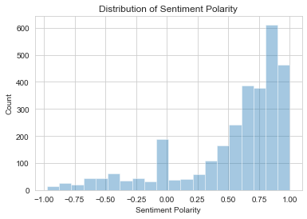

```python
sns.distplot(data.sentiment_polarity,bins=20,kde = False)
plt.xlabel("Sentiment Polarity")
plt.ylabel("Count")
plt.title("Distribution of Sentiment Polarity")
```

###### Distribution of Ratings given by User

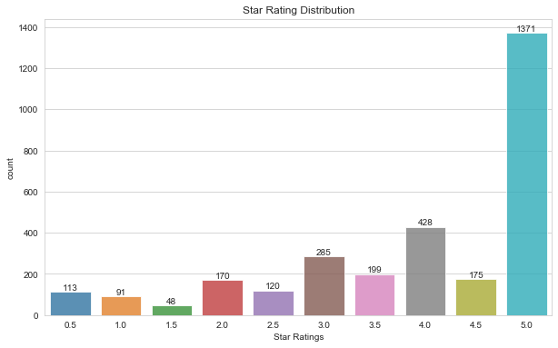

```python
x=data['Rating'].value_counts()
x=x.sort_index()
plt.figure(figsize=(10,6))
ax= sns.barplot(x.index, x.values, alpha=0.8)
plt.title("Star Rating Distribution")
plt.ylabel('count')
plt.xlabel('Star Ratings')
rects = ax.patches
labels = x.values
for rect, label in zip(rects, labels):
    height = rect.get_height()
    ax.text(rect.get_x()+ rect.get_width()/2,height,label, ha='center', va='bottom')

plt.show();
```

###### Comparison of Sentiment Polarities Between Positive and Negative Reviews.

</p>Eventhough Review is taken as Negative, polarity is still more than 0 which can mean that user might be praising certain aspects of the movie.</p>

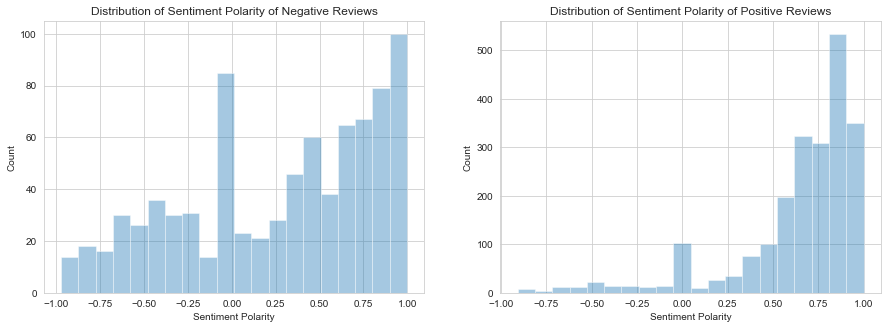

```python
plt.figure(figsize=(15,5))

plt.subplot(1, 2, 1)
neg_rev_polarity = data.loc[data["Target"] == 0 , ["sentiment_polarity"]]
sns.distplot(neg_rev_polarity,bins=20,kde = False)
plt.xlabel("Sentiment Polarity")
plt.ylabel("Count")
plt.title("Distribution of Sentiment Polarity of Negative Reviews")


plt.subplot(1, 2, 2)
pos_rev_polarity = data.loc[data["Target"] == 1 , ["sentiment_polarity"]]
sns.distplot(pos_rev_polarity,bins=20,kde = False)
plt.xlabel("Sentiment Polarity")
plt.ylabel("Count")
plt.title("Distribution of Sentiment Polarity of Positive Reviews")
```

###### Most Frequently used words in Negative Reviews.

</p>WordCloud Suggests people are talking about Voice acting, Characters, expression, and comapring the movie with original.</p>

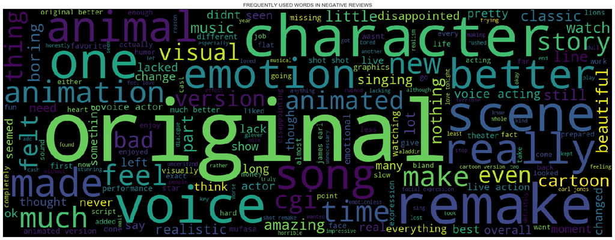

```python
neg_review = data.loc[data["Target"]==0 , :]
neg_reviews  = " ".join(text for text in neg_review["Text"])
cloud=WordCloud(width=1600, height=600).generate(neg_reviews)


plt.figure(figsize=(20,10))
plt.axis("off")
plt.title("FREQUENTLY USED WORDS IN NEGATIVE REVIEWS")
plt.imshow(cloud)
plt.tight_layout(pad=0)
plt.show(cloud)
```

###### Most Frequently used words in Positive Reviews.

</p>WordCloud Suggests people are talking about graphic, cgi,remake, and comapring the movie with original.</p>

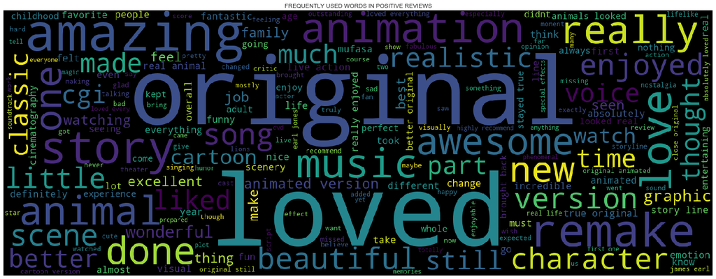

```python
pos_reviews = data.loc[data["Target"]==1 , :]
pos_reviews  = " ".join(text for text in pos_reviews["Text"])
cloud=WordCloud(width=1600, height=600).generate(pos_reviews)

plt.figure(figsize=(20,10))
plt.axis("off")
plt.title("FREQUENTLY USED WORDS IN POSITIVE REVIEWS")
plt.imshow(cloud)
plt.tight_layout(pad=0)
plt.show(cloud)
```

###### All capital words in reviews that stressed certain points are like CGI , Realistic, few of the characters names, Graphics, voices, slow etc.

[figure not shown]

```python
all_caps = data.loc[: ,["All_caps_words"]]
all_caps = all_caps.loc[all_caps["All_caps_words"] !=0 ,:]
all_caps['All_caps_words'] = all_caps['All_caps_words'].apply(','.join)
all_caps['All_caps_words'] = [re.sub(","," ",text) for text in all_caps["All_caps_words"]]
all_caps["All_caps_words"] = all_caps['All_caps_words'].apply(lambda x: [x for x in x.split() if x.lower() not in stopword])
all_caps["All_caps_words"] = all_caps['All_caps_words'].apply(lambda x: " ".join(x))

all_caps_reviews  = ["".join(text) for text in all_caps["All_caps_words"]]
all_caps_reviews  = " ".join(text for text in  all_caps_reviews)
cloud=WordCloud(width=1600, height=600).generate(all_caps_reviews)

plt.figure(figsize=(20,10))
plt.axis("off")
plt.title("FREQUENTLY CAPITALIZED WORDS")
plt.imshow(cloud)
plt.tight_layout(pad=0)
plt.show(cloud)
```

##### VERY IMP EDA

The most Frequent and meaningful Bi-grams in negative Reviews were "voice acting","facial expressions","no emotion".

```python
text = ' '.join(data.loc[data.Target == 0, 'Text'].values)
text = [i for i in text.split() if i not in stopword]
text_trigrams = [i for i in ngrams(text, 2)]
Counter(text_trigrams).most_common(15)
```

```
[(('did', 'not'), 165),
 (('voice', 'acting'), 41),
 (('live', 'action'), 30),
 (('animated', 'version'), 27),
 (('voice', 'actors'), 26),
 (('much', 'better'), 26),
 (('shot', 'shot'), 26),
 (('original', 'better'), 24),
 (('james', 'earl'), 20),
 (('earl', 'jones'), 19),
 (('original', 'not'), 19),
 (('facial', 'expressions'), 19),
 (('shot', 'remake'), 18),
 (('feel', 'love'), 18),
 (('no', 'emotion'), 18)]
```

The most Frequent and meaningful Tri-grams in positive Reviews were "better than original","animals looked real"

```python
text = ' '.join(data.loc[data.Target == 1, 'Text'].values)
text = [i for i in text.split() if i not in stopword]
text_trigrams = [i for i in ngrams(text, 3)]
Counter(text_trigrams).most_common(10)
```

```
[(('better', 'than', 'original'), 27),
 (('james', 'earl', 'jones'), 21),
 (('stayed', 'true', 'original'), 20),
 (('animals', 'looked', 'real'), 16),
 (('original', 'animated', 'version'), 15),
 (('feel', 'love', 'tonight'), 10),
 (('brought', 'back', 'many'), 9),
 (('very', 'true', 'original'), 9),
 (('did', 'amazing', 'job'), 9),
 (('loved', 'every', 'minute'), 8)]
```

```python
text = ' '.join(data.loc[data.Target == 0, 'Text'].values)
text = [i for i in text.split() if i not in stopword]
text_trigrams = [i for i in ngrams(text, 3)]
Counter(text_trigrams).most_common(10)
```

```
[(('james', 'earl', 'jones'), 19),
 (('shot', 'shot', 'remake'), 18),
 (('feel', 'love', 'tonight'), 16),
 (('did', 'not', 'feel'), 13),
 (('original', 'much', 'better'), 10),
 (('did', 'not', 'live'), 9),
 (('did', 'not', 'make'), 7),
 (('original', 'did', 'not'), 7),
 (('did', 'not', 'really'), 6),
 (('watching', 'national', 'geographic'), 6)]
```

```python
### TEST PREPROCESS

test['Text'] = [expand_contractions(re.sub('’', "'", review)) for review in test['Review']]

test = multi_punctuation_numbers(test)

test = emoji(test)

test["All_caps_words"] = test["All_caps_words"].apply(empty_list)
test["emoji"] = test["emoji"].apply(empty_list)
test["emoji_meaning"] = test["emoji_meaning"].apply(empty_list)

test["emoticons"] = 0
test["emoticons"] = test["emoticons"].apply(emoticons_map)

test["Text"] = [remove_accented_chars(text) for text in test['Text'] ]

test["Text_Tokens"] = test['Text'].apply(lambda x: [x.lower() for x in x.split() if x.lower() not in stopword])
test["Text"] = test['Text_Tokens'].apply(lambda x: " ".join(x))


test['sentiment_polarity'] = test.Review.apply(vader_polarity_scores)

test.head()
```

[output not shown]

## Word Embedding

```python
w2v = gensim.models.Word2Vec(data["Text_Tokens"], size=100,\
                             window=10, min_count=2, \
                             iter=20)
words = list(w2v.wv.vocab)
print("vocabulary size: ",len(words))
```

```
vocabulary size:  2250
```

```python
# Saving the word Embedding

filename = 'lion_king_reviews_word2vec.txt'
w2v.wv.save_word2vec_format(filename , binary=False)
```

```python
# Function to draw graph for most similar words

def word_network(word ,n):
    if len(word) == 1:
        list1 = w2v.most_similar([word],topn = n)
    else:
        list1 = w2v.most_similar(positive=word,topn = n)
    plt.figure(figsize=(20,10))
    G = nx.DiGraph()
    for i in range(0,n):
        G.add_edges_from([(list1[i][0],word)], weight= (list1[i][1]))

    pos = nx.spring_layout(G)
    nx.draw(G, pos, arrows=True,node_size = 5500,node_shape='o',with_labels=True,)

    plt.draw()
    plt.show()

    return
```

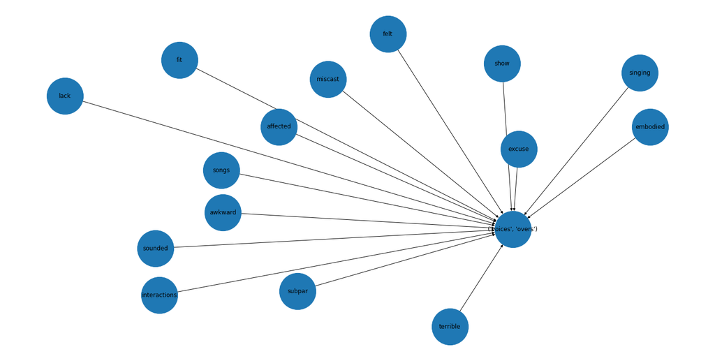

```python
word_network(('voices',"overs"),15)
```

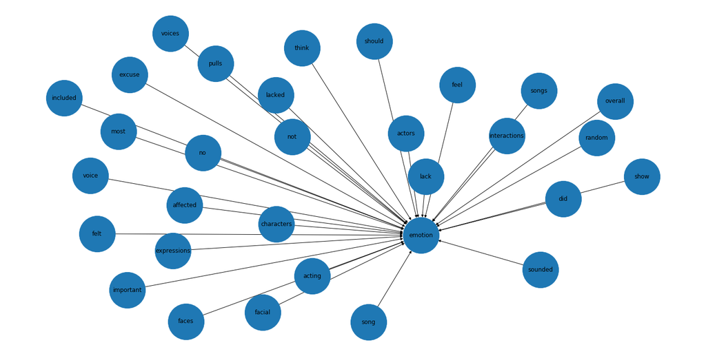

```python
word_network(('emotion'),30)
```

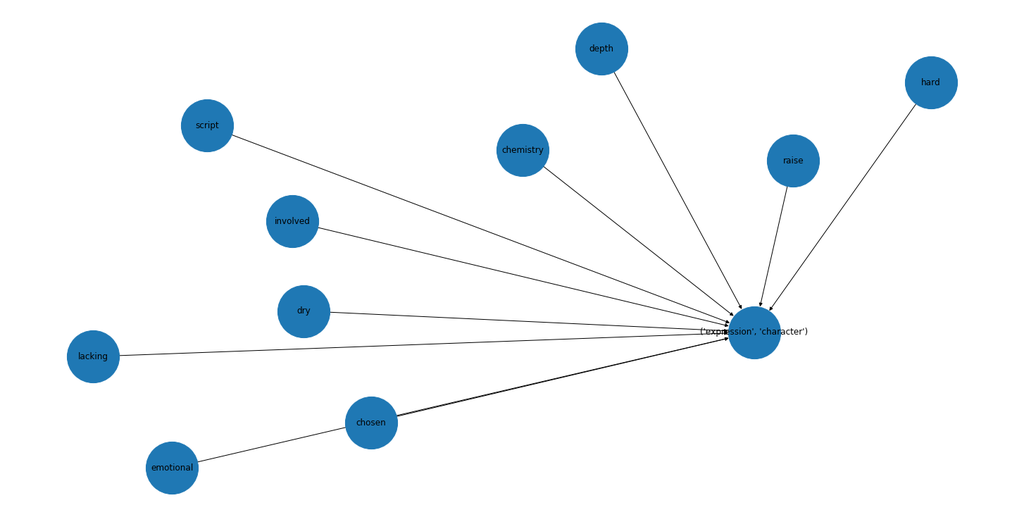

```python
word_network(('expression',"character"),10)
```

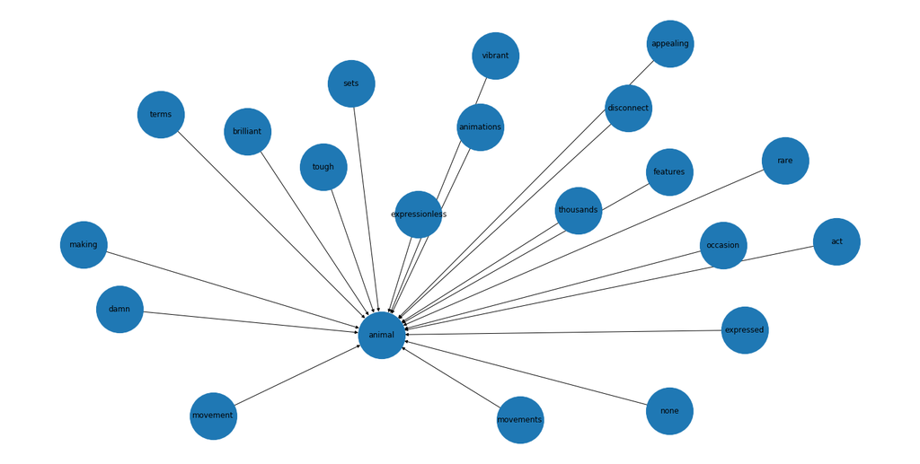

```python
word_network(('animal'),20)
```

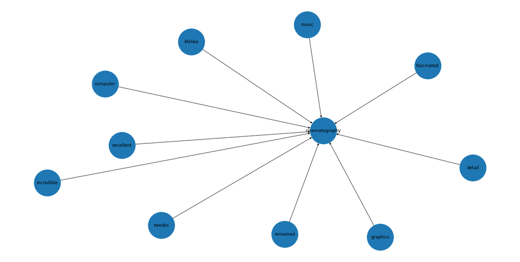

```python
word_network(('cinematography'),10)
```

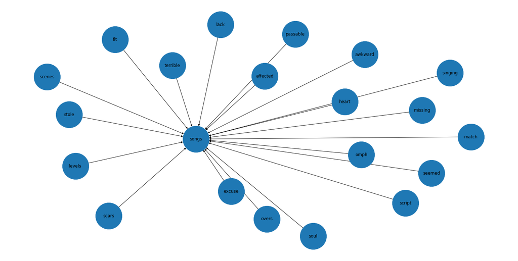

```python
word_network(('songs'),20)
```

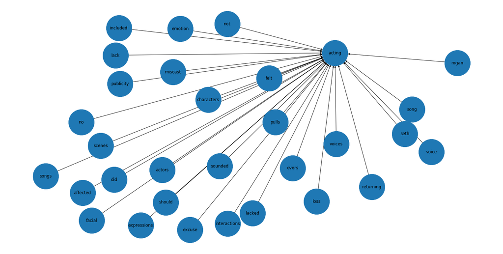

```python
word_network("acting",n=30)
```

###### Checkpoint for word embedding on just Train Reviews

```python
# Creating embedding index on train

embeddings_index = {}

f= open('E:\Insofe\datasets\PHd\PHD_ProblemstatementandInstructions\EDA\lion_king_reviews_word2vec.txt',\
        encoding = "utf-8")
for line in f:
    values = line.split()
    word = values[0]
    coefs = np.asarray(values[1:])
    embeddings_index[word] = coefs

f.close()
```

```python
max_length = max([len(s.split()) for s in data["Review"]])

tokenizer = Tokenizer(oov_token='None')
tokenizer.fit_on_texts(data["Text_Tokens"])

sequences = tokenizer.texts_to_sequences(data["Text_Tokens"])
test_sequences = tokenizer.texts_to_sequences(test["Text_Tokens"])

word_index = tokenizer.word_index

print("No unique tokes: ",len(word_index))

review_padded = pad_sequences(sequences , maxlen = max_length)
test_review_padded = pad_sequences(test_sequences , maxlen = max_length)

labels = data["Target"].values

print(review_padded.shape)
print(labels.shape)
```

```
No unique tokes:  4722
(3000, 776)
(3000,)
```

```python
# Creating Embedding layer
```

```python
num_words = len(word_index) + 1
EMBEDDING_DIM = 100
embedding_matrix = np.zeros((num_words, EMBEDDING_DIM))

for word, i in word_index.items():
    if i > num_words:
        continue
    embedding_vector = embeddings_index.get(word)
    if embedding_vector is not None:
        embedding_matrix[i] = embedding_vector
```

```python
review_text_input= Input(shape=(max_length,),name='review_text_input')

text_embed = Embedding(input_dim=num_words,\
                           output_dim=EMBEDDING_DIM,\
                           weights=[embedding_matrix],\
                           trainable=False)(review_text_input)
review_out_text = Flatten()(text_embed)
```

```python
# Layer for nuemerical data
```

```python
num_inputs = Input(shape=(1,),\
                       name='num_inputs')
out_num = Dense(64, activation='relu')(num_inputs)
```

1 layer 8 neuorns , 0.89 on Test Labelled , 0.62 on Test </p>

```python
concatenated = concatenate([out_num,review_out_text],axis=-1)
X = Dense(8, activation='relu')(concatenated)
final_out = Dense(1, activation='sigmoid')(X)

model_1 = Model(inputs=[num_inputs,review_text_input], outputs=final_out)


model_1.summary()

model_1.compile(loss='binary_crossentropy',\
              optimizer='adagrad', metrics=['accuracy'])

model_1.fit([np.asarray(data["sentiment_polarity"]),
           review_padded],
          y=data["Target"],
          epochs=10,validation_split=0.20,verbose=2)

embedding_pred= model_1.predict([np.asarray(test["sentiment_polarity"]),
           test_review_padded])


for i in range(len(embedding_pred)):
    if embedding_pred[i] > 0.5:
        embedding_pred[i] = 0
    else:
        embedding_pred[i] = 1

embedding_pred = pd.DataFrame(embedding_pred,\
                             columns = ["sentiment"])
embedding_pred["ReviewID"] = test["ReviewID"]

embedding_pred = embedding_pred.reindex(columns=["ReviewID","sentiment"])
embedding_pred.to_csv("submission_embedded_1_nn.csv",index=False)
```

```
__________________________________________________________________________________________________
Layer (type)                    Output Shape         Param #     Connected to
==================================================================================================
review_text_input (InputLayer)  (None, 776)          0
__________________________________________________________________________________________________
num_inputs (InputLayer)         (None, 1)            0
__________________________________________________________________________________________________
embedding_2 (Embedding)         (None, 776, 100)     472300      review_text_input[0][0]
__________________________________________________________________________________________________
dense_1 (Dense)                 (None, 64)           128         num_inputs[0][0]
__________________________________________________________________________________________________
flatten_2 (Flatten)             (None, 77600)        0           embedding_2[0][0]
__________________________________________________________________________________________________
concatenate_3 (Concatenate)     (None, 77664)        0           dense_1[0][0]
                                                                 flatten_2[0][0]
__________________________________________________________________________________________________
dense_6 (Dense)                 (None, 8)            621320      concatenate_3[0][0]
__________________________________________________________________________________________________
dense_7 (Dense)                 (None, 1)            9           dense_6[0][0]
==================================================================================================
Total params: 1,093,757
Trainable params: 621,457
Non-trainable params: 472,300
__________________________________________________________________________________________________
Train on 2400 samples, validate on 600 samples
 - 2s - loss: 0.4528 - acc: 0.7733 - val_loss: 0.3951 - val_acc: 0.8033
 - 2s - loss: 0.3875 - acc: 0.8054 - val_loss: 0.3726 - val_acc: 0.8267
 - 2s - loss: 0.3721 - acc: 0.8233 - val_loss: 0.3618 - val_acc: 0.8450
 - 2s - loss: 0.3607 - acc: 0.8321 - val_loss: 0.3604 - val_acc: 0.8417
 - 2s - loss: 0.3534 - acc: 0.8346 - val_loss: 0.3635 - val_acc: 0.8400
 - 2s - loss: 0.3473 - acc: 0.8408 - val_loss: 0.3695 - val_acc: 0.8333
 - 2s - loss: 0.3422 - acc: 0.8383 - val_loss: 0.3663 - val_acc: 0.8367
 - 2s - loss: 0.3363 - acc: 0.8450 - val_loss: 0.3671 - val_acc: 0.8417
 - 2s - loss: 0.3314 - acc: 0.8525 - val_loss: 0.3699 - val_acc: 0.8450
 - 2s - loss: 0.3292 - acc: 0.8504 - val_loss: 0.3738 - val_acc: 0.8367
```

</p> Total Embedding 3 LSTM and 2 Layer, 0.67 test

```python
model_2 = Sequential()
model_2.add(Embedding(input_dim=num_words,\
                           output_dim=EMBEDDING_DIM,\
                           weights=[embedding_matrix],\
                           trainable=False))

model_2.add(LSTM(10, return_sequences=True))
model_2.add(LSTM(5, return_sequences=True))
model_2.add(LSTM(5, return_sequences=False))

model_2.add(Dense(64, activation='relu'))
model_2.add(Dense(64, activation='relu'))
model_2.add(Dense(1, activation='sigmoid'))

model_2.summary()

model_2.compile(loss='binary_crossentropy',\
              optimizer='adagrad', metrics=['accuracy'])

model_2.fit([review_padded],
          y=data["Target"],
          epochs=10,validation_split=0.20,verbose=2)

embedding_pred= model_2.predict([test_review_padded])

for i in range(len(embedding_pred)):
    if embedding_pred[i] > 0.5:
        embedding_pred[i] = 0
    else:
        embedding_pred[i] = 1

embedding_pred = pd.DataFrame(embedding_pred,\
                             columns = ["sentiment"])
embedding_pred["ReviewID"] = test["ReviewID"]

embedding_pred = embedding_pred.reindex(columns=["ReviewID","sentiment"])
embedding_pred.to_csv("submission_embedded_3_lstm_2_nn.csv",index=False)
```

```
_________________________________________________________________
Layer (type)                 Output Shape              Param #
=================================================================
embedding_3 (Embedding)      (None, None, 100)         472300
_________________________________________________________________
lstm_1 (LSTM)                (None, None, 10)          4440
_________________________________________________________________
lstm_2 (LSTM)                (None, None, 5)           320
_________________________________________________________________
lstm_3 (LSTM)                (None, 5)                 220
_________________________________________________________________
dense_8 (Dense)              (None, 64)                384
_________________________________________________________________
dense_9 (Dense)              (None, 64)                4160
_________________________________________________________________
dense_10 (Dense)             (None, 1)                 65
=================================================================
Total params: 481,889
Trainable params: 9,589
Non-trainable params: 472,300
_________________________________________________________________
Train on 2400 samples, validate on 600 samples
 - 106s - loss: 0.5064 - acc: 0.7558 - val_loss: 0.4467 - val_acc: 0.7633
 - 95s - loss: 0.4467 - acc: 0.7633 - val_loss: 0.4358 - val_acc: 0.7600
 - 97s - loss: 0.4401 - acc: 0.7721 - val_loss: 0.4316 - val_acc: 0.7917
 - 95s - loss: 0.4368 - acc: 0.7783 - val_loss: 0.4215 - val_acc: 0.7800
 - 95s - loss: 0.4330 - acc: 0.7788 - val_loss: 0.4398 - val_acc: 0.7700
 - 96s - loss: 0.4302 - acc: 0.7783 - val_loss: 0.4159 - val_acc: 0.7783
 - 95s - loss: 0.4269 - acc: 0.7775 - val_loss: 0.4115 - val_acc: 0.7800
 - 95s - loss: 0.4238 - acc: 0.7783 - val_loss: 0.4145 - val_acc: 0.7833
 - 97s - loss: 0.4217 - acc: 0.7804 - val_loss: 0.4108 - val_acc: 0.7900
 - 95s - loss: 0.4188 - acc: 0.7883 - val_loss: 0.4058 - val_acc: 0.7850
```

</p> With check point and 0.2 dropout 3 LSTM and 3 NN layer

```python
# BEST FOR STACKING adam, wt: mdl_wts_93.h5

def scheduler(epoch):
    if epoch < 5 :
        return 0.001
    else:
        return 0.001 * math.exp(0.1 * (10 - epoch))

lr_scheduler = LearningRateScheduler(scheduler)
model_checkpoint = ModelCheckpoint('mdl_wts.h5', verbose=1, monitor='val_loss',save_best_only=True, mode='min')

model_3 = Sequential()
model_3.add(Embedding(input_dim=num_words,\
                           output_dim=EMBEDDING_DIM,\
                           weights=[embedding_matrix],\
                           trainable=False))


model_3.add(LSTM(15, return_sequences=True))
model_3.add(LSTM(10, return_sequences=True))
model_3.add(LSTM(5, return_sequences=False))

model_3.add(Dropout(0.2))

model_3.add(Dense(128, activation='relu',kernel_initializer = "uniform"))
model_3.add(Dense(64, activation='relu',kernel_initializer = "uniform"))
model_3.add(Dense(32, activation='relu',kernel_initializer = "uniform"))

model_3.add(Dense(1, activation='sigmoid'))

model_3.summary()

model_3.compile(loss='binary_crossentropy',\
              optimizer='adam', metrics=['accuracy'])

model_3.fit([review_padded],
          y=data["Target"],
          epochs=10,validation_split=0.20,verbose=0, callbacks=[lr_scheduler ,model_checkpoint ])

model_3 = load_model('mdl_wts.h5')

embedding_pred_3_drop= model_3.predict([test_review_padded])

for i in range(len(embedding_pred_3_drop)):
    if embedding_pred_3_drop[i] > 0.5:
        embedding_pred_3_drop[i] = 0
    else:
        embedding_pred_3_drop[i] = 1

embedding_pred = pd.DataFrame(embedding_pred_3_drop,\
                             columns = ["sentiment"])
embedding_pred["ReviewID"] = test["ReviewID"]

embedding_pred = embedding_pred.reindex(columns=["ReviewID","sentiment"])
embedding_pred.to_csv("submission_embedded_3_lstm_3_nn.csv",index=False)
```

```
_________________________________________________________________
Layer (type)                 Output Shape              Param #
=================================================================
embedding_6 (Embedding)      (None, None, 100)         472300
_________________________________________________________________
lstm_10 (LSTM)               (None, None, 15)          6960
_________________________________________________________________
lstm_11 (LSTM)               (None, None, 10)          1040
_________________________________________________________________
lstm_12 (LSTM)               (None, 5)                 320
_________________________________________________________________
dropout_3 (Dropout)          (None, 5)                 0
_________________________________________________________________
dense_19 (Dense)             (None, 128)               768
_________________________________________________________________
dense_20 (Dense)             (None, 64)                8256
_________________________________________________________________
dense_21 (Dense)             (None, 32)                2080
_________________________________________________________________
dense_22 (Dense)             (None, 1)                 33
=================================================================
Total params: 491,757
Trainable params: 19,457
Non-trainable params: 472,300
_________________________________________________________________

Epoch 00001: val_loss improved from inf to 0.58000, saving model to mdl_wts.h5

Epoch 00002: val_loss improved from 0.58000 to 0.46748, saving model to mdl_wts.h5

Epoch 00003: val_loss improved from 0.46748 to 0.45390, saving model to mdl_wts.h5

Epoch 00004: val_loss improved from 0.45390 to 0.43239, saving model to mdl_wts.h5

Epoch 00005: val_loss did not improve from 0.43239

Epoch 00006: val_loss did not improve from 0.43239

Epoch 00007: val_loss improved from 0.43239 to 0.42833, saving model to mdl_wts.h5

Epoch 00008: val_loss improved from 0.42833 to 0.42213, saving model to mdl_wts.h5

Epoch 00009: val_loss did not improve from 0.42213

Epoch 00010: val_loss improved from 0.42213 to 0.41373, saving model to mdl_wts.h5
```

```python
# Subsetting Reviews and Sentiment polarities for model building
```

```python
X = data.loc[ : , ["Text","sentiment_polarity"]]
Y = data["Target"]
```

```python
# Splitting dat for training and Validation
```

```python
from sklearn.model_selection import train_test_split

X_train , X_val , Y_train , Y_val = train_test_split(X,Y,test_size = 0.2 , random_state=12)
```

</p> Creating TF-IDF vector far train, validation and test data

```python
tfidf_vectorizer = TfidfVectorizer(ngram_range=(1,2))

tfidf_transformer = tfidf_vectorizer.fit(X_train["Text"])
tfidf_train = tfidf_vectorizer.transform(X_train["Text"])
tfidf_val = tfidf_vectorizer.transform(X_val["Text"])
```

```python
tfidf_whole_train = tfidf_vectorizer.fit_transform(X["Text"])
tfidf_final_test = tfidf_vectorizer.transform(test["Text"])
```

</p>Fiting svc on train and validating on validation data

```python
from sklearn.metrics import f1_score , classification_report,
classifier = SVC(C=3,
                kernel='rbf',gamma=1
                )
classifier.fit(tfidf_train,Y_train)

svc_val_pred = classifier.predict(tfidf_val)

print(classification_report(Y_val, svc_val_pred))
```

```
              precision    recall  f1-score   support

           0       0.79      0.63      0.70       171
           1       0.86      0.93      0.90       429

    accuracy                           0.84       600
   macro avg       0.82      0.78      0.80       600
weighted avg       0.84      0.84      0.84       600
```

</p> Fiting svm on whole train text data and predicting on test text data, 0.72 f-score on test data

```python
classifier = SVC(C=3,
                kernel='rbf',gamma=1
                )
classifier.fit(tfidf_whole_train,Y)

svc_test_pred = classifier.predict(tfidf_final_test)

for i in range(len(svc_test_pred)):
    if svc_test_pred[i] == 1 :
        svc_test_pred[i] = 0
    else:
        svc_test_pred[i] = 1

svc_test_pred_DF = pd.DataFrame(svc_test_pred,\
                             columns = ["sentiment"])
svc_test_pred_DF["ReviewID"] = test["ReviewID"]

svc_test_pred_DF = svc_test_pred_DF.reindex(columns=["ReviewID","sentiment"])
svc_test_pred_DF.to_csv("submission_svc.csv",index=False)
```

</p> Fiting svm on train text Sentiment Polarity data and predicting on validation text text Sentiment Polarity.

```python
polarity_train = np.array(X_train["sentiment_polarity"]).reshape(-1,1)
polarity_val = np.array(X_val["sentiment_polarity"]).reshape(-1,1)
polarity_test = np.array(test["sentiment_polarity"]).reshape(-1,1)

polarity_classifier = SVC(C=100,
                kernel='rbf',gamma=1
                )
polarity_classifier.fit(polarity_train,Y_train)

svc_polarity_val_pred= polarity_classifier.predict(polarity_val)

print(classification_report(Y_val, svc_polarity_val_pred))
```

```
              precision    recall  f1-score   support

           0       0.59      0.22      0.32       171
           1       0.75      0.94      0.83       429

    accuracy                           0.73       600
   macro avg       0.67      0.58      0.58       600
weighted avg       0.70      0.73      0.69       600
```

</p> Fiting svm on whole train text Sentiment Polarity and predicting on test text Sentiment Polarity data.

```python
polarity_train_whole = np.array(X["sentiment_polarity"]).reshape(-1,1)
polarity_test = np.array(test["sentiment_polarity"]).reshape(-1,1)

polarity_classifier = SVC(C=100,
                kernel='rbf',gamma=1
                )
polarity_classifier.fit(polarity_train_whole,Y)
svc_polarity_test_pred = polarity_classifier.predict(polarity_test)

for i in range(len(svc_polarity_test_pred)):
    if svc_polarity_test_pred[i] == 1 :
        svc_polarity_test_pred[i] = 0
    else:
        svc_polarity_test_pred[i] = 1

svc_polarity_test_DF = pd.DataFrame(svc_polarity_test_pred,\
                             columns = ["sentiment"])
svc_polarity_test_DF["ReviewID"] = test["ReviewID"]

svc_polarity_test_DF = svc_polarity_test_DF.reindex(columns=["ReviewID","sentiment"])
svc_polarity_test_DF.to_csv("submission_polarity_svc.csv",index=False)
```

</p> Stacking of Embedding_LSTM , Svm, Svm_polarity. 0.72 on Test

```python
model_3 = load_model('mdl_wts.h5')
embedding_test_pred= model_3.predict([test_review_padded])

for i in range(len(embedding_test_pred)):
    if embedding_test_pred[i] >= 0.5 :
        embedding_test_pred[i] = 1
    else:
        embedding_test_pred[i] = 0

stack = pd.DataFrame(embedding_test_pred , columns=["embedding_pred_layer"])

stack["Svc_pred"] = svc_test_pred
stack["Svc_pred_polarity"] = svc_polarity_test_pred


stack["MODE_PRED"]=stack.iloc[:,:3].mode(axis=1)

stack["MODE_PRED"] = stack["MODE_PRED"].astype('int64')
stack_pred = stack["MODE_PRED"]
stack_pred = np.array(stack_pred)

for i in range(len(stack_pred)):
    if stack_pred[i] == 1 :
        stack_pred[i] = 0
    else:
        stack_pred[i] = 1
stack_pred = pd.DataFrame(stack_pred,columns = ["sentiment"])
stack_pred = pd.DataFrame(stack_pred,columns = ["sentiment"])
stack_pred["ReviewID"] = test["ReviewID"]

stack_pred = stack_pred.reindex(columns=["ReviewID","sentiment"])
stack_pred.to_csv("submission_stack.csv",index=False)
```

</p> Logistic Regression on Train Text data. 0.73 on Test

```python
log_reg = LogisticRegression(C=3)
log_reg.fit(tfidf_train,Y_train)

log_reg_val_pred = log_reg.predict(tfidf_val)
print(classification_report(Y_val,log_reg_val_pred))
```

```
              precision    recall  f1-score   support

           0       0.78      0.63      0.70       171
           1       0.86      0.93      0.89       429

    accuracy                           0.84       600
   macro avg       0.82      0.78      0.80       600
weighted avg       0.84      0.84      0.84       600
```

```python
log_reg = LogisticRegression(C=3)
log_reg.fit(tfidf_whole_train,Y)

log_reg_test_pred = log_reg.predict(tfidf_final_test)


for i in range(len(log_reg_test_pred)):
    if log_reg_test_pred[i] == 1 :
        log_reg_test_pred[i] = 0
    else:
        log_reg_test_pred[i] = 1

log_reg_test_pred_DF = pd.DataFrame(log_reg_test_pred,columns = ["sentiment"])
log_reg_test_pred_DF["ReviewID"] = test["ReviewID"]

log_reg_test_pred_DF = log_reg_test_pred_DF.reindex(columns=["ReviewID","sentiment"])
log_reg_test_pred_DF.to_csv("submission_logreg.csv",index=False)
```

</p> Stacking Logistic Regression , SVM , SVM for Sentiment Polarity. 0.73 on test data

```python
stack = pd.DataFrame(log_reg_test_pred , columns=["Log_reg_pred"])

stack["Svc_pred"] = svc_test_pred
stack["Svc_pred_polarity"] = svc_polarity_test_pred

stack["MODE_PRED"]=stack.iloc[:,:3].mode(axis=1)

stack["MODE_PRED"] = stack["MODE_PRED"].astype('int64')
stack_pred = stack["MODE_PRED"]
stack_pred = np.array(stack_pred)

for i in range(len(stack_pred)):
    if stack_pred[i] == 1 :
        stack_pred[i] = 0
    else:
        stack_pred[i] = 1
stack_pred = pd.DataFrame(stack_pred,columns = ["sentiment"])
stack_pred = pd.DataFrame(stack_pred,columns = ["sentiment"])
stack_pred["ReviewID"] = test["ReviewID"]

stack_pred = stack_pred.reindex(columns=["ReviewID","sentiment"])
stack_pred.to_csv("submission_stack_2.csv",index=False)
```

</p> K-means Clustering of TF-IDF Vectors of Train Data

```python
tfidf_vectorizer = TfidfVectorizer()
tfidf_whole_train = tfidf_vectorizer.fit_transform(X["Text"])
tfidf_final_test = tfidf_vectorizer.transform(test["Text"])
```

```python
dense_train = tfidf_whole_train.todense()
dense_test = tfidf_final_test.todense()
```

```python
feature_names = tfidf_vectorizer.get_feature_names()
DF_train = pd.DataFrame(dense_train)
DF_train.columns = feature_names
```

```python
num_clusters = 2
kmeans_model = KMeans(n_clusters=num_clusters, init = 'k-means++')
kmeans_model.fit(DF_train,Y)
```

```
KMeans(algorithm='auto', copy_x=True, init='k-means++', max_iter=300,
       n_clusters=2, n_init=10, n_jobs=None, precompute_distances='auto',
       random_state=None, tol=0.0001, verbose=0)
```

```python
print("Top terms per cluster:")

order_centroids = kmeans_model.cluster_centers_.argsort()[:, ::-1]

for i in range(num_clusters):
    print()
    print("Top words in Cluster-%d :" % i, end='')
    print()
    for ind in order_centroids[i, :30]:
        print('%s' % feature_names[ind].split(' '), end=',')
```

```
Top terms per cluster:

Top words in Cluster-0 :
['loved'],['original'],['amazing'],['everything'],['absolutely'],['real'],['animals'],['music'],['true'],['family'],['awesome'],['very'],['looked'],['stayed'],['animation'],['did'],['every'],['wonderful'],['job'],['whole'],['love'],['realistic'],['would'],['story'],['beautiful'],['remake'],['took'],…
Top words in Cluster-1 :
['original'],['not'],['very'],['did'],['amazing'],['better'],['love'],['really'],['animals'],['version'],['story'],['animation'],['enjoyed'],['remake'],['awesome'],['much'],['one'],['animated'],['real'],['beautiful'],['would'],['liked'],['done'],['cartoon'],['more'],['music'],['same'],['than'],['sti…
```

```python
# common_words = model.cluster_centers_.argsort()[:,:]
# for num, centroid in enumerate(common_words):
#     print(str(num) + ' : ' + ', '.join(feature_names[word] for word in centroid))
```

```python
labels = pd.DataFrame(kmeans_model.labels_ ,columns=["K_Lables"])
```

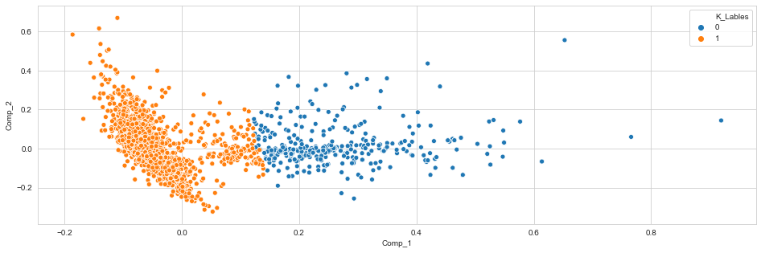

```python
pca = PCA(n_components=2)
pca.fit(dense_train)
principal_comp = pca.transform(dense_train)

pca_df = pd.DataFrame(data= principal_comp , columns = ["Comp_1","Comp_2"])

pca_df_final = pd.concat([pca_df,labels], axis =1)

pca_df_final["K_Lables"]=pca_df_final["K_Lables"].astype("category")
pca_df_final["Actual_Target"] = data["Target"]


plt.figure(figsize=(16,5))

sns.scatterplot(data=pca_df_final,x='Comp_1', y='Comp_2', hue='K_Lables')
```

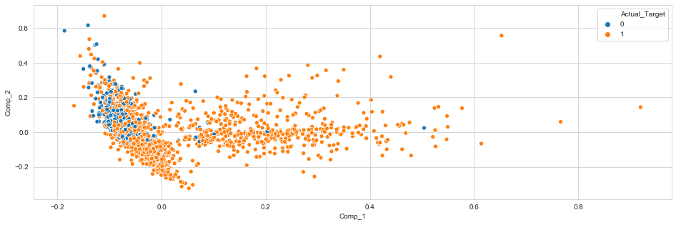

```python
# Plotting 2 Components of PCA according to Train Labels
plt.figure(figsize=(16,5))
sns.scatterplot(x='Comp_1', y='Comp_2', hue='Actual_Target',
                       data=pca_df_final)
```

**Summary And Recommendation:**

As this movie was a remake people already had emotions attached with the original movie and it's important for the production house to know what audiences are looking for from such remakes for future references. After analysis, I would like to recommend that voice over actors should be either same as the original movie had or at least similar to them. And if any new technology is being used then to make sure that it brings out the same emotions as in the original movie.